# Simulation studies for mis-classification in non-probability surveys

Author

Maciej Beręsewicz

## Basic setup

Read the packages for the simulation studies

```r
library(simex) ## only confusion matrix is provided
library(nonprobsvy)
library(data.table)
library(vcd)
library(VIM)
library(ggplot2)
library(knitr)
```

## Simulation study

I use a modified simulation study from the section 10.3 from **Biffignandi, S., & Bethlehem, J. (2021). Handbook of web surveys. John Wiley & Sons**. (second edition).

- **Age** in three categories:
  - Young (with probability 0.40),
  - Middle-aged (with probability 0.35), and
  - Old (with probability 0.25).
- **Ethnic origin** in two categories:
  - Native (with probability 0.85) and
  - Nonnative (with probability 0.15).
- **Having access to Internet** with two categories: Yes and No according to the following table

|  |  | Yes | No |
| --- | --- | --- | --- |
| Native | Young | 0.90 | 0.10 |
|  | Middle-aged | 0.70 | 0.30 |
|  | Old | 0.50 | 0.50 |
| Non-native | Young | 0.25 | 0.75 |
|  | Middle-aged | 0.15 | 0.85 |
|  | Old | 0.10 | 0.90 |

- **Voted for the National Elderly Party** (NEP). The probability to vote for this party depended on age only:
  - Probabilities were 0.05 (for Young),
  - 0.40 (for Middle-aged), and
  - 0.60 (for Old).
- **Voted for the New Internet Party** (NIP). The probability to vote for this party depended on both age and having Internet. For people with Internet access, the probabilities were 0.80 (for Young), 0.40 (for Middle-aged), and 0.20 (for Old). For people without Internet access, all probabilities were equal to 0.10 . So, for people with Internet voting decreased with age. The voting probability was low for people without Internet.

[output not shown]

Codes to generate population data

```r
set.seed(2024)
N <- 100000
pop_data <- data.table(age = sample(c("Young", "Middle-aged", "Old"), size = N, c(0.40, 0.35, 0.25), replace = T),
                       ethnic = sample(c("Native", "Nonnative"), size = N, prob = c(0.85, 0.15), replace = T))

pop_data[ethnic == "Native" & age == "Young", internet := rbinom(.N, 1, 0.90)]
pop_data[ethnic == "Native" & age == "Middle-aged", internet := rbinom(.N, 1, 0.70)]
pop_data[ethnic == "Native" & age == "Old", internet := rbinom(.N, 1, 0.50)]

pop_data[ethnic == "Nonnative" & age == "Young", internet := rbinom(.N, 1, 0.25)]
pop_data[ethnic == "Nonnative" & age == "Middle-aged", internet := rbinom(.N, 1, 0.15)]
pop_data[ethnic == "Nonnative" & age == "Old", internet := rbinom(.N, 1, 0.10)]

pop_data[age == "Young", NEP := rbinom(.N, 1, 0.05)]
pop_data[age == "Middle-aged", NEP := rbinom(.N, 1, 0.40)]
pop_data[age == "Old", NEP := rbinom(.N, 1, 0.60)]

pop_data[age == "Young" & internet == 1, NIP := rbinom(.N, 1, 0.80)]
pop_data[age == "Middle-aged" & internet == 1, NIP := rbinom(.N, 1, 0.40)]
pop_data[age == "Old" & internet == 1, NIP := rbinom(.N, 1, 0.20)]
pop_data[internet == 0, NIP := rbinom(.N, 1, 0.10)]

pop_data[, age := factor(age, levels = c("Young", "Middle-aged", "Old"))]
pop_data[, ethnic := factor(ethnic, levels = c("Native", "Nonnative"))]
pop_data[, pi_A := exp(-2 + 2*internet) / (1 + exp(-2 + 2*internet))]
```

## Definition of mis-classification matrices

For ethnicity, the mis-classification matrix is defined as follows:

$$\Gamma_{ethnic} = \begin{bmatrix}
0.7 & 0.05 \\
0.3 & 0.95
\end{bmatrix}$$
where rows correspond to mis-classified levels (1 row = native, 2 row= non-native). This mean that original native people are classified as native with probability 0.70 and as non-native with probability 0.30.

The matrix for age is given below.

$$\Gamma_{age} = \begin{bmatrix}
0.85 & 0.20 & 0.05 \\
0.15 & 0.70 & 0.15 \\
0.05 & 0.10 & 0.80
\end{bmatrix}$$

This means that original young people are classified as young with probability 0.85, as middle-aged with probability 0.15, and as old with probability 0.05.

Codes to create matrix

```r
gamma_ethnic <- matrix(c(0.7, 0.3, 0.05, 0.95), ncol = 2)
gamma_age <- matrix(c(0.85, 0.15, 0.05,
                      0.20, 0.70, 0.10,
                      0.05, 0.15, 0.80), ncol = 3)

colnames(gamma_age) <- levels(pop_data$age)
colnames(gamma_ethnic) <- levels(pop_data$ethnic)
```

Here, I create the matrix of new variables age* and ethnic* based on sampling from a given matrix.

```r
set.seed(2024)
dd <- simex::misclass(pop_data[, .(age, ethnic)],
                      list(age = gamma_age, ethnic = gamma_ethnic),
                      k = 1)
pop_data[, age_m := dd$age]
pop_data[, ethnic_m := dd$ethnic]
```

The empirical classification based on this matrix is as follows

```r
xtabs(~age_m + age, data = pop_data) |> prop.table(2) |> knitr::kable()
```

|  | Young | Middle-aged | Old |
| --- | --- | --- | --- |
| Young | 0.8106387 | 0.2001880 | 0.0475181 |
| Middle-aged | 0.1410057 | 0.6997465 | 0.1499540 |
| Old | 0.0483556 | 0.1000655 | 0.8025279 |

```r
xtabs(~ethnic_m + ethnic, data = pop_data) |> prop.table(2)  |> knitr::kable()
```

|  | Native | Nonnative |
| --- | --- | --- |
| Native | 0.7009784 | 0.0482427 |
| Nonnative | 0.2990216 | 0.9517573 |

## How mis-classification changes dependence with NEP?

I measure the relationship between NEP given covariates and NEP given mis-classified covariates. I use Cramer’s V as a measure of association.

1. NEP and age / NEP and age*

```r
c(original = assocstats(xtabs(~NEP + age, data = pop_data))$cramer,
  with_error = assocstats(xtabs(~NEP + age_m, data = pop_data))$cramer) |> knitr::kable()
```

|  | x |
| --- | --- |
| original | 0.4884794 |
| with_error | 0.3527058 |

2. NEP and ethnicity and NEP and ethnicity*

```r
c(original = assocstats(xtabs(~NEP + ethnic, data = pop_data))$cramer,
  with_error = assocstats(xtabs(~NEP + ethnic_m, data = pop_data))$cramer)  |> knitr::kable()
```

|  | x |
| --- | --- |
| original | 0.0004735 |
| with_error | 0.0002637 |

3. age and ethnicity / age* and ethnicity*

```r
c(original = assocstats(xtabs(~age + ethnic, data = pop_data))$cramer,
  with_error = assocstats(xtabs(~age_m + ethnic_m, data = pop_data))$cramer)  |> knitr::kable()
```

|  | x |
| --- | --- |
| original | 0.0047728 |
| with_error | 0.0038957 |

Summary:

- mis-classification decrease the strength of the relationship
- NEP and ethnicity is not correlated
- age and ethnicity are independent (as defined, this may be changed)

## Details regarding the simulation study

### Selection mechanisms

We consider the following selection mechanism of non-probability and probability sample

$$P(k \in S_A) = \frac{\exp(-2 + 2\times \text{Internet})}{1+ \exp(-2 + 2\times \text{Internet})}$$

– selection to probability sample ($S_B$): simple random sampling of size $n_B = 1000$

– for measuring the mis-classification w we assume a stratified random sampling from $S_A$ where each level of mis-classified variables is represented by 100 observations (in total represents 600 observations).

### Estimation

The goal is to estimate share of people voting for NEP (we do not consider NIP yet). We consider the following estimators:

- sample mean based on probability sample $S_B$ – `nep_srs`
- naive - sample mean based on $S_A$ – `nep_naive`

We consider the following mass imputation estimators:

- based on variables measured without error – `mi_cor`
- based on variables measured with error – `mi_err`
- based on variables measured with error and corrected by MC-SIMEX approach – `mi_li`, `mi_qu`, `mi_ll`
- based on variables measured with error where true values of age and ethnic are imputed using random forest – `mi_imp`

We report:

- bias,
- variance,
- rmse,
- empirical coverage rate of 95% confidence interval

### Code for simulation study

```r
set.seed(123)
n_sims <- 100 ## number of simulations
n_B <- 1000
n_valid <- 100 ## size of validation sample
stratified <- TRUE
B_simex <- 50
results  <- list()

for (r in 1:n_sims) {

  if (r %% 10 == 0) print(r)

  S_A <- copy(pop_data[rbinom(.N, 1, pi_A) == 1])
  S_A[, id:=1:.N]

  S_B <- copy(pop_data[sample(1:.N, n_B)])
  S_B[, weights := N/n_B]
  S_B_svy <- svydesign(ids = ~1, data = S_B, weights = ~weights)

  est_sb <- svymean(~NEP + NIP, design = S_B_svy)
  est_sa_naive <- colMeans(S_A[, .(NEP, NIP)])

  est_sa_mi <- nonprob(
    outcome = NEP + NIP ~ age + ethnic,
    data = S_A,
    svydesign = S_B_svy,
    method_outcome = "glm",
    family_outcome = "binomial"
  )

  ## with errors (estimated from S_A only)
  S_A_err <- copy(S_A)

  if (stratified) {
    S_A_err[, w:=.N/n_valid, .(age_m, ethnic_m)]
    S_A_err_valid_sample <- copy(S_A_err[,.SD[sample(.N, n_valid)], by = .(age_m, ethnic_m)])
  } else {
    S_A_err[, w:=.N/(n_valid*6)]
    S_A_err_valid_sample <- copy(S_A_err[sample(1:.N, n_valid*6)])
  }

  sampled_ids <- S_A_err_valid_sample$id
  error_age <- as.matrix(prop.table(xtabs(w~ age_m + age, data = S_A_err_valid_sample), margin = 2))
  error_eth <- as.matrix(prop.table(xtabs(w~ ethnic_m + ethnic, data = S_A_err_valid_sample), margin = 2))
  S_A_err[, age := NULL]
  S_A_err[, ethnic := NULL]
  S_A_err[, age := age_m]
  S_A_err[, ethnic := ethnic_m]

  est_sa_mi_errors <- nonprob(
    outcome = NEP + NIP ~ age + ethnic,
    data = S_A_err,
    svydesign = S_B_svy,
    method_outcome = "glm",
    family_outcome = "binomial"
  )

  est_sa_mi_err <- glm(NEP ~ age + ethnic, family = binomial, x = TRUE, y = TRUE,
                       data = S_A_err)

  ## model parameters corrected by MC-SIMEX approach
  res_mi_li <- tryCatch(simex::mcsimex(model = est_sa_mi_err,
                              mc.matrix = list(age = error_age, ethnic = error_eth),
                              SIMEXvariable = c("age", "ethnic"),
                              fitting.method    = "linear",
                              asymptotic = FALSE,
                              jackknife.estimation  = FALSE,
                              B = B_simex), error = function(e) NULL)

  if (is.null(res_mi_li)) next

  res_mi_qu <- refit(object = res_mi_li,
                     fitting.method = "quadratic",
                     asymptotic = FALSE,
                     jackknife.estimation   = FALSE)

  res_mi_ll <- refit(object = res_mi_qu,
                     fitting.method = "loglinear",
                     asymptotic = FALSE,
                     jackknife.estimation   = FALSE)

  S_B_svy <- update(S_B_svy,
         NEP_li = predict(res_mi_li, S_B_svy$variables, type = "response"),
         NEP_qu = predict(res_mi_qu, S_B_svy$variables, type = "response"),
         NEP_ll = predict(res_mi_ll, S_B_svy$variables, type = "response"))

  res <- svymean(~NEP_li + NEP_qu + NEP_ll, design = S_B_svy)
  res_ci <- confint(res)

  ## assume that we sample subsample and have only partial information
  S_A_imputation <- copy(S_A)
  S_A_imputation[!id %in% sampled_ids, ":="(age = NA, ethnic = NA)]

  S_A_imputation_kk <- rangerImpute(formula = age + ethnic ~ age_m + ethnic_m ,
                                    data = S_A_imputation)

  S_A_imputation[, age:= S_A_imputation_kk$age]
  S_A_imputation[, ethnic:= S_A_imputation_kk$ethnic]

  est_sa_mi_imp <- nonprob(
    outcome = NEP + NIP ~ age + ethnic,
    data = S_A_imputation,
    svydesign = S_B_svy,
    method_outcome = "glm",
    family_outcome = "binomial"
  )


  results[[r]] <- data.frame(
    nep_srs = est_sb[1],
    nep_naive = est_sa_naive[1],
    nep_mi = est_sa_mi$output$mean[1],
    nep_err = est_sa_mi_errors$output$mean[1],
    nep_li = res[1],
    nep_qu = res[2],
    nep_ll = res[3],
    nep_imp = est_sa_mi_imp$output$mean[1],
    cr_cor = est_sa_mi$confidence_interval[1, 1] < mean(pop_data$NEP) & est_sa_mi$confidence_interval[1, 2] > mean(pop_data$NEP),
    cr_err = est_sa_mi_errors$confidence_interval[1, 1] < mean(pop_data$NEP) & est_sa_mi_errors$confidence_interval[1, 2] > mean(pop_data$NEP),
    cr_li = res_ci[1, 1] < mean(pop_data$NEP) & res_ci[1, 2] > mean(pop_data$NEP),
    cr_qu = res_ci[2, 1] < mean(pop_data$NEP) & res_ci[2, 2] > mean(pop_data$NEP),
    cr_ll = res_ci[3, 1] < mean(pop_data$NEP) & res_ci[3, 2] > mean(pop_data$NEP),
    cr_imp = est_sa_mi_imp$confidence_interval[1, 1] < mean(pop_data$NEP) & est_sa_mi_imp$confidence_interval[1, 2] > mean(pop_data$NEP)
  )
}
```

```
[1] 10
[1] 20
[1] 30
[1] 40
[1] 50
[1] 60
[1] 70
[1] 80
[1] 90
[1] 100
```

```r
results_df <- rbindlist(results, idcol = "rep")
```

Boxplot of point estimates from simulations

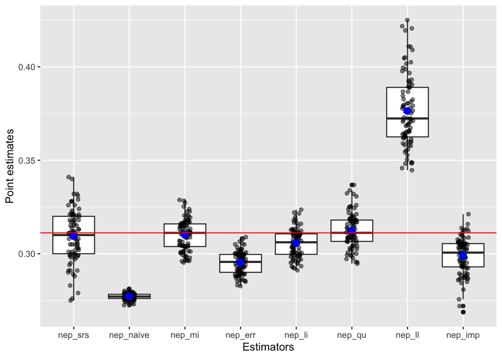

Figure 1

```r
results_df[,1:9] |>
  melt(id.vars = 1) |>
  ggplot(data = _, aes(x = variable, y= value)) +
  geom_boxplot() +
  geom_jitter(width = 0.1, alpha = 0.5) +
  stat_summary(fun = mean, color = "blue", geom = "point", size = 3) +
  geom_hline(yintercept = mean(pop_data$NEP), col = "red") +
  labs(x = "Estimators", y = "Point estimates")
```

Coverage rate

```r
colMeans(results_df[,10:15]) |> kable()
```

|  | x |
| --- | --- |
| cr_cor | 0.8941176 |
| cr_err | 0.2117647 |
| cr_li | 0.7294118 |
| cr_qu | 0.8352941 |
| cr_ll | 0.0000000 |
| cr_imp | 0.7529412 |

Results of the simulation

```r
results_df[,1:9] |>
  melt(id.vars = 1) |>
  {\(x) x[, .(bias = mean(value) - mean(pop_data$NEP),
              sd = sd(value),
              rmse = sqrt( (mean(value) - mean(pop_data$NEP))^2 + var(value))), variable]}() |>
  transform(bias = bias*100, sd=sd*100, rmse=rmse*100) |>
  kable()
```

| variable | bias | sd | rmse |
| --- | --- | --- | --- |
| nep_srs | -0.1724706 | 1.3759367 | 1.3867039 |
| nep_naive | -3.4042298 | 0.1769385 | 3.4088250 |
| nep_mi | -0.1175848 | 0.8365264 | 0.8447500 |
| nep_err | -1.5979534 | 0.6237415 | 1.7153741 |
| nep_li | -0.5459556 | 0.7568954 | 0.9332514 |
| nep_qu | 0.1180924 | 0.9321774 | 0.9396279 |
| nep_ll | 6.5185268 | 1.9261334 | 6.7971451 |
| nep_imp | -1.2311269 | 1.0017155 | 1.5871696 |